# AirBnb Pricing Analysis

Carolyn Radle & Heather McCabe

7/6/2021

## Abstract

The following is an analysis covering the data that we used to support the claims made in our blog post, and how we manipulated the data as we worked with it. Our blog post summarized our findings from the dataset we used, containing thousands of AirBnb listings from 2019, and specific information on each.

## Overview and Motivation

We decided to do a data analysis focusing on factors that affect the price of NYC AirBnb listings. Tourism in NYC is extremely popular, so we wanted to look into what factors make up the expenses of these listings. This is an interesting location to analyze, because although it is a large tourist destination, as it hosts sports games, Broadway shows, and much more, New York is also the home to over 8 million people. Therefore, it is also a very popular city to travel to for work related reasons. As AirBnb is slowly disrupting the hotel industry, we felt that it would be interesting to look into the factors that allow listings to have such a high price tag.

## Related Work

This article came to our attention prior to being introduced to this project. https://news.airbnb.com/airbnb-seeks-12-people-to-live-anywhere-for-one-year/ We both are college students who have been to several AirBnb homes. We love to travel, but price is the most notable factor that keeps us from doing so. This topic resonates with us strongly, and that is why we found such interest in our dataset and topic.

## Initial Questions

We wanted to find out which factors affected AirBnb listing prices, and which factors do not. At the beginning of our analysis, we were not sure if we would focus on pricing or popularity of listings, but as shown below in the Exploratory Data Analysis section, we ended up working mostly with prices. We wanted to form questions that would be meaningful to our audience, and could potentially help them in their decision making on an AirBnb listing down the road.

Our initial questions were:

- Does neighborhood/borough affect price?
- Does property type / amount of space affect price?
- Does certain words in the listing affect price?
- Is there a correlation between availability of listing and price?
- Is there a correlation between minimum nights and price?

We go into more detail about how we went about these questions, and why we did not answer all of them in the sections below.

## Data

At first, we pulled data using two datasets: AB_NYC_2019 (https://www.kaggle.com/dgomonov/new-york-city-airbnb-open-data) and Airbnb_NYC (https://www.kaggle.com/sarthakniwate13/air-bnb-nyc-data). After making a few plots, we realized that the data was pretty much the same in both, which we were happy with; that meant that they probably reflected similar listings and the data was more likely to be accurate. Since one dataset alone had almost 50,000 observations, we felt that there was no need for both. We ultimately chose AB_NYC_2019 to be our sole dataset because it had more observations, and it included the listing descriptions, which we felt could be useful as we went deeper into our analysis. Also, AB_NYC_2019 clearly specifies that its data is from 2019 listings, whereas Airbnb_NYC does not specify a timeframe.

```r
library(tidyverse)
library(gridExtra)
library(data.table)
library(leaflet)
library(kableExtra)
AB_NYC_2019<-read.csv("/Users/carolynradle/Documents/Math 488P/2_eda/data/AB_NYC_2019.csv")
colnames(AB_NYC_2019)
```

```
##  [1] "id"                             "name"
##  [3] "host_id"                        "host_name"
##  [5] "neighbourhood_group"            "neighbourhood"
##  [7] "latitude"                       "longitude"
##  [9] "room_type"                      "price"
## [11] "minimum_nights"                 "number_of_reviews"
## [13] "last_review"                    "reviews_per_month"
## [15] "calculated_host_listings_count" "availability_365"
```

```r
AB_NYC_2019 <- rename(AB_NYC_2019, borough = neighbourhood_group)
```

The dataset has 16 columns. We wanted to utilize the majority of them to our benefit, so that we could really analyze which factors had the biggest effect on price. We changed the name of the “neighbourhood_group” column to be called “borough,” for less confusion between that and the “neighbourhood” column.

In the beginning stages of our analysis, we thought that it would be interesting to look at price vs the availability per year. We went ahead and took a look at how the availability per year column looked:

```r
head(AB_NYC_2019$availability_365, 10)
```

```
##  [1] 365 355 365 194   0 129   0 220   0 188
```

In just the first 10 rows, we noticed that the data was a little suspicious, because some listings had 365 day availability, and some had 0. The numbers in the 100s and 200s looked more normal to us. We thought about the many reasons listings could be available or unavailable: maybe family of the host or the host themselves are staying in the apartment for the time being, maybe the host is not active in booking out their listings, and then of course maybe the listing is super popular or unpopular to the general public based on how it is perceived on the app. Either way, we cannot control why the availability numbers are the way they are, and there were too many 0’s and high 300 numbers that we were not comfortable with. Taking out this data was also an option, but maybe those apartments were just super popular or unpopular, and we did not want to skew the data too much, so we decided to abandon this column altogether.

The “name” column, which is the listing descriptions as mentioned before, really caught our eye.

```r
head(AB_NYC_2019$name, 10)
```

```
##  [1] "Clean & quiet apt home by the park"
##  [2] "Skylit Midtown Castle"
##  [3] "THE VILLAGE OF HARLEM....NEW YORK !"
##  [4] "Cozy Entire Floor of Brownstone"
##  [5] "Entire Apt: Spacious Studio/Loft by central park"
##  [6] "Large Cozy 1 BR Apartment In Midtown East"
##  [7] "BlissArtsSpace!"
##  [8] "Large Furnished Room Near B'way "
##  [9] "Cozy Clean Guest Room - Family Apt"
## [10] "Cute & Cozy Lower East Side 1 bdrm"
```

Going through the rows of this column, we noticed that most hosts used adjectives that could not be measured to describe their home. We liked the words “cozy” and “luxury,” because although both are meant to be positive adjectives, they could describe very different listings. We wanted to see if these words correlated to different prices for their respective listings.

## Exploratory Data Analysis

We began our analysis by not being completely sure if we were going to compare most of our factors to price, or to popularity of listings. The data contains columns such as “number_of_reviews”, “reviews_per_month,” etc. This would be beneficial to compare other factors to the popularity of a listing, in absence of the availability column as mentioned earlier. We also utilized the actual number of listings in our analysis, because this definitely showed us where the popular AirBnb areas are. This was one of the first plots we made:

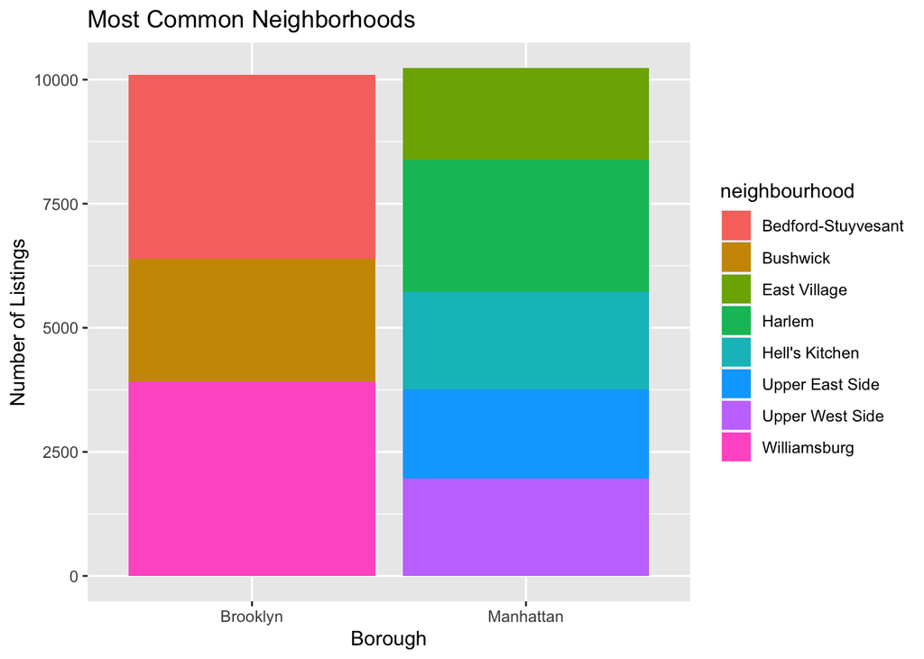

```r
AB_NYC_2019 %>%
    group_by(neighbourhood) %>%
    summarize(num_listings = n(),
              borough = unique(borough)) %>%
    top_n(n = 8, wt = num_listings) %>%
    ggplot(aes(x = borough,
               y = num_listings, fill = neighbourhood)) +
    geom_col() +
    labs(title = "Most Common Neighborhoods",
         x = "Borough" , y = "Number of Listings")
```

This graphic gave us a good idea of the most common neighborhoods for NYC travel. We then decided to see if the most common neighborhoods were similar to the most expensive neighborhoods.

```r
pop_neighborhoods <- AB_NYC_2019 %>%
  group_by(neighbourhood) %>%
  summarize(num_listings= n(),
            borough = unique(borough),
            median_price = median(price)
            ) %>%
  arrange(desc(median_price))
head(pop_neighborhoods, 15)
```

```
## # A tibble: 15 x 4
##    neighbourhood      num_listings borough       median_price
##    <chr>                     <int> <chr>                <dbl>
##  1 Fort Wadsworth                1 Staten Island         800
##  2 Woodrow                       1 Staten Island         700
##  3 Tribeca                     177 Manhattan             295
##  4 Neponsit                      3 Queens                274
##  5 NoHo                         78 Manhattan             250
##  6 Willowbrook                   1 Staten Island         249
##  7 Flatiron District            80 Manhattan             225
##  8 Midtown                    1545 Manhattan             210
##  9 Financial District          744 Manhattan             200
## 10 West Village                768 Manhattan             200
## 11 Chelsea                    1113 Manhattan             199
## 12 SoHo                        358 Manhattan             199
## 13 Greenwich Village           392 Manhattan             198.
## 14 Battery Park City            70 Manhattan             195
## 15 Breezy Point                  3 Queens                195
```

Once we came to the conclusion that the most expensive listings are not among the most popular, we decided to focus on the factors that correlate to higher prices of listings , rather than merely popularity, because price is the largest consideration for prospective travelers. Therefore, in order to make this data meaningful, we wanted to have a focus that resonates with most other travelers.

We took out the listings in our pop_neighborhoods dataset that had less than 5 listings, and we graphed the top 10 most expensive neighborhoods by median price, which all happened to be in Manhattan.

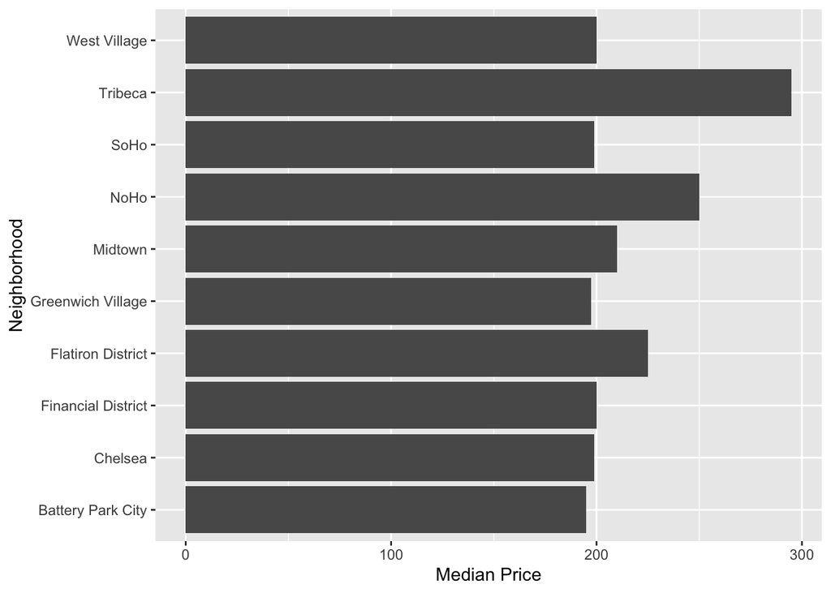

```r
most_exp_neighborhoods <- pop_neighborhoods[c(3,5,7,8,9,10,11,12,13,14),]

most_exp_neighborhoods %>%
  ggplot() + geom_col(aes(x = neighbourhood, y = median_price)) + coord_flip() + labs(x = "Neighborhood" , y = "Median Price")
```

We chose to focus on the median price rather than the mean price, because we did not want to account for the many outliers that we know are present. We instead accounted for those outliers in our map of NYC, mapping the 40 most expensive AirBnbs, which ranged from $3,600 to $8,000.

We chose to filter out the listings with a minimum stay of 5 days or more, because a stay that long is not too popular with NYC travelers, so it wouldn’t make sense to compare that to a listing with a minimum stay of 1 or 2 days.

```r
top_listings <- AB_NYC_2019 %>% filter(minimum_nights <5) %>% top_n(n = 40, wt = price) %>% arrange(desc(price))
head(top_listings, 10)
```

```
##          id                                      name   host_id host_name
## 1   2953058                             Film Location   1177497   Jessica
## 2  22779726 East 72nd Townhouse by (Hidden by Airbnb) 156158778     Sally
## 3  33007610       70' Luxury MotorYacht on the Hudson   7407743      Jack
## 4  34895693                      Gem of east Flatbush 262534951    Sandra
## 5  33998396          3000 sq ft daylight photo studio   3750764     Kevin
## 6   2271504          SUPER BOWL Brooklyn Duplex Apt!!  11598359  Jonathan
## 7  22780103 Park Avenue Mansion by (Hidden by Airbnb) 156158778     Sally
## 8  12520066        Luxury townhouse Greenwich Village  66240032     Linda
## 9   2243699       SuperBowl Penthouse Loft 3,000 sqft   1483320      Omri
## 10  1448703       Beautiful 1 Bedroom in Nolita/Soho     213266   Jessica
##      borough     neighbourhood latitude longitude       room_type price
## 1   Brooklyn      Clinton Hill 40.69137 -73.96723 Entire home/apt  8000
## 2  Manhattan   Upper East Side 40.76824 -73.95989 Entire home/apt  7703
## 3  Manhattan Battery Park City 40.71162 -74.01693 Entire home/apt  7500
```

[output cut: 29 more lines]

We included in our blog post the map of where these top 40 unbiased listings are located. To do this, we used the longitude and latitude coordinates given in the dataset, and the r package “leaflet.” We felt that it was extremely important to add this visual element, to show that the most expensive listings are not all crowded in the same place, or even in the same borough. Navy blue points represent entire homes, and grey points represent a private room in a home.

```r
pal <- colorFactor(c("navy", "grey"),
                   domain = c("Entire home/apt", "Private Room"))


leaflet(top_listings) %>%
  addTiles("Most Expensive NYC AirBnb Listings") %>%
  setView(-74.00, 40.71, zoom = 12) %>%
  addProviderTiles("CartoDB.Positron") %>%
  addCircleMarkers(
    radius = 10,
    color = ~pal(room_type),
    stroke = TRUE
)
```

```
## Assuming "longitude" and "latitude" are longitude and latitude, respectively
```

[interactive chart not shown]

Due to the variability of this graph and our data, we cannot make an assumption of the cause for these high prices. We can guess that the price of these listings have more to do with the space themselves, rather than the area of the city they are in, because besides for a few closeby in lower manhattan, the top 40 listings seem spread out.

We then wanted to create a plot that summarized all of the AirBnb prices in a simple, concise way. After developing several different types of plots, we decided that the boxplot would fit our data the best, since we had a lot of outliers that needed to be accounted for. We first separated our plot by price and room type:

```r
AB_NYC_2019 %>%
  group_by(room_type) %>%
  summarize(
     N = n(),
    avg_price = mean(price),
    med_price = median(price)
  )
```

```
## # A tibble: 3 x 4
##   room_type           N avg_price med_price
##   <chr>           <int>     <dbl>     <dbl>
## 1 Entire home/apt 25409     212.        160
## 2 Private room    22326      89.8        70
## 3 Shared room      1160      70.1        45
```

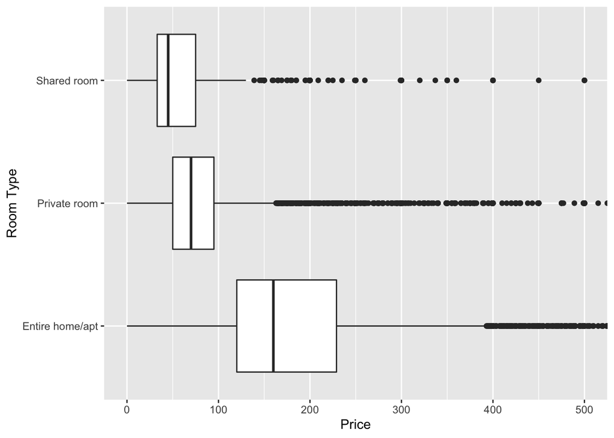

```r
AB_NYC_2019 %>%
  filter%>%
  ggplot() + geom_boxplot(mapping = aes(x = price, y = room_type))+
  coord_cartesian(xlim =c(0, 500)) + labs(y = "Room Type", x = "Price")
```

We created an x-axis limit of 500 because it is well above the mean of each room type, but with 500 as the limit you can still get a good view of the outliers. This graph was a good starting point, but we needed to separate it further. We already know that the boroughs play a big role in the different prices, so we let color map to the room type, and we changed the y-axis to represent each borough.

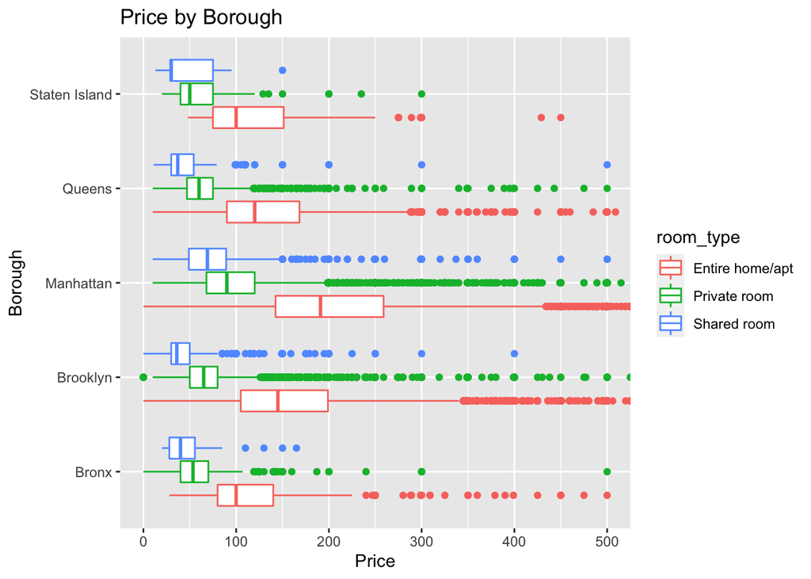

```r
AB_NYC_2019 %>%
  ggplot() + geom_boxplot(aes(x = price, y = borough, color = room_type)) +
  coord_cartesian(xlim =c(0, 500)) + labs(x = "Price", y = "Borough", title = "Price by Borough")
```

```r
AB_NYC_2019 %>%
  group_by(borough, room_type) %>%
  summarize(
    N = n(),
    avg_price = mean(price)
  )
```

```
## # A tibble: 15 x 4
## # Groups:   borough [5]
##    borough       room_type           N avg_price
##    <chr>         <chr>           <int>     <dbl>
##  1 Bronx         Entire home/apt   379     128.
##  2 Bronx         Private room      652      66.8
##  3 Bronx         Shared room        60      59.8
##  4 Brooklyn      Entire home/apt  9559     178.
##  5 Brooklyn      Private room    10132      76.5
##  6 Brooklyn      Shared room       413      50.5
##  7 Manhattan     Entire home/apt 13199     249.
##  8 Manhattan     Private room     7982     117.
##  9 Manhattan     Shared room       480      89.0
## 10 Queens        Entire home/apt  2096     147.
## 11 Queens        Private room     3372      71.8
## 12 Queens        Shared room       198      69.0
## 13 Staten Island Entire home/apt   176     174.
## 14 Staten Island Private room      188      62.3
## 15 Staten Island Shared room         9      57.4
```

Lastly, we utilized the “name” column of the dataset to filter out certain words in the listing descriptions that we felt may have a correlation to price. We also filtered the borough to only be Manhattan to try to control bias as much as possible. In all honesty, this part of our data is not super meaningful in that it will help readers determine how to find cheaper listings, because we do not believe that these words hold a direct impact on the price. However, we think that it is interesting that cheaper than average listings tend to contain the word “Cozy,” while more expensive than average listings tend to contain the word “Luxury”:

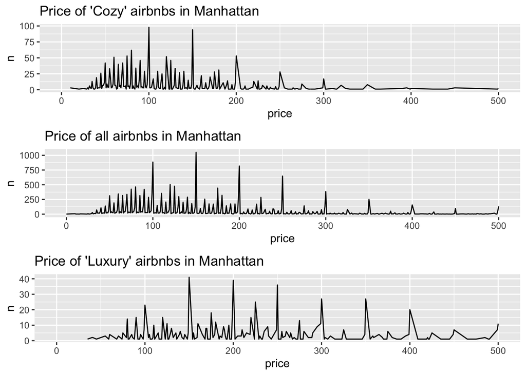

```r
cozy_rooms <- AB_NYC_2019 %>%
  filter(borough == "Manhattan" , grepl( "Cozy | cozy" , name))

x <- cozy_rooms %>%
  group_by(price) %>%
  summarise(n=n()) %>%
  ggplot() + geom_line(aes(x = price, y = n)) + xlim(0,500) + labs(title = "Price of 'Cozy' airbnbs in Manhattan")


totals <- AB_NYC_2019 %>%
  filter(borough == "Manhattan")

y <- totals  %>%
  group_by(price) %>%
  summarise(n=n()) %>%
  ggplot() + geom_line(aes(x = price, y = n))+ xlim(0,500) + labs(title = "Price of all airbnbs in Manhattan")


luxury_rooms <- AB_NYC_2019 %>%
  filter(borough == "Manhattan" , grepl( "Luxury | luxury" , name))

z <- luxury_rooms %>%
  group_by(price) %>%
  summarise(n=n()) %>%
  ggplot() + geom_line(aes(x = price, y = n)) +
  xlim(0,500) + labs(title = "Price of 'Luxury' airbnbs in Manhattan")

grid.arrange(x,y,z)
```

When we made these graphs, we felt that they did a great job in portraying that Luxury AirBnbs tend to be more expensive than average, and there are far less of them overall. However, the graphs for all AirBnbs and “Cozy” AirBnbs seem very similar with these graphs, even though we know with our computations, they are actually quite different. This is why in our blog post, we stuck to the mean and median prices, rather than the graphs:

```r
c<- cozy_rooms %>%
  summarize(
    count = n(),
    Word = "Cozy",
    mean(price),
    median(price)
  )

l<- luxury_rooms%>%
  summarize(
    count = n(),
    Word = "Luxury",
    mean(price),
    median(price)
  )

t <-totals%>%
  summarize(
    count = n(),
    Word = "Total",
    mean(price),
    median(price)
  )

alist <- list(c,l,t)
rbindlist(alist)
```

```
##    count   Word mean(price) median(price)
## 1:  1857   Cozy    129.5256           109
## 2:   925 Luxury    324.8249           220
## 3: 21661  Total    196.8758           150
```

```r
blist <- rbindlist(alist)
kbl(blist) %>%
  kable_styling(bootstrap_options = "striped", full_width = F)
```

| count | Word | mean(price) | median(price) |
| --- | --- | --- | --- |
| 1857 | Cozy | 129.5256 | 109 |
| 925 | Luxury | 324.8249 | 220 |
| 21661 | Total | 196.8758 | 150 |

This is much simpler to read, and it definitely conveys our point, with and without outliers.

## Final Analysis

From our data analysis, we have found that room type, neighborhood and borough have an affect on the price of NYC AirBnb listings. We also have found that being in a neighborhood with more listings does not affect the price of AirBnb listings. We were not able to determine whether there are correlations between availability of the listing, and minimum nights and price. The dataset did not provide us enough information to make these assumptions. We also determined that the price of AirBnbs containing the word “cozy” in their description seem to be lower than average. Also the price of AirBnbs containing the word “luxury” in their description seem to be higher than average. These words are just observations, not a direct cause of the price. Overall, each of these factors work together to determine the price of an AirBnb listing, so there is no single variable that changes the prices. However, these variables may have a large affect on the final price tag for an AirBnb listing.